# Marketing Data Analysis

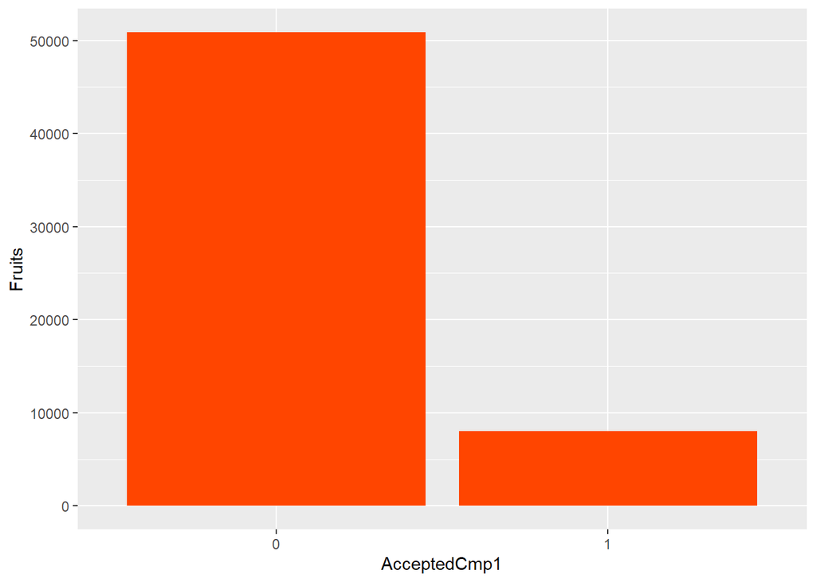

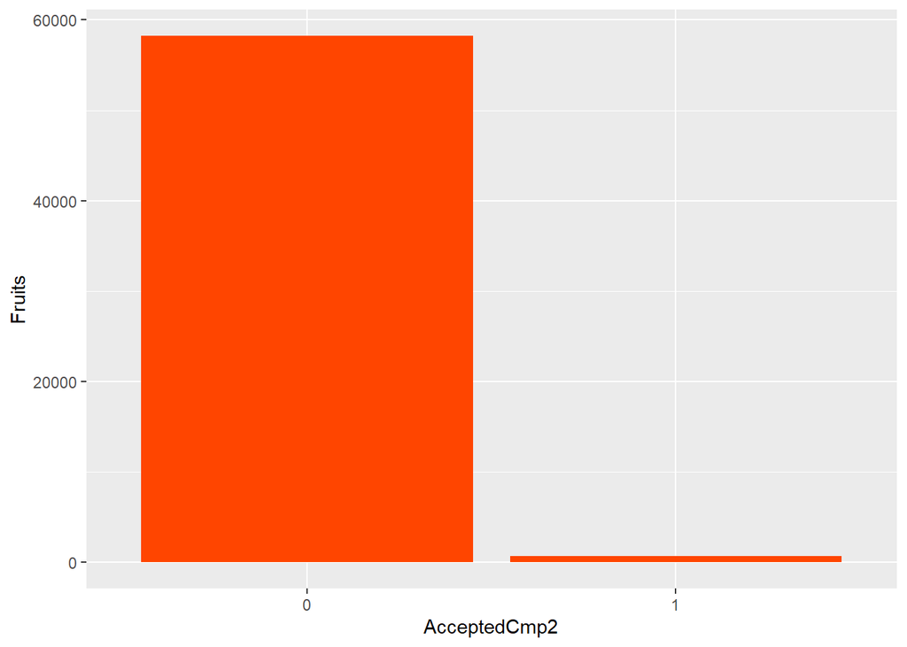

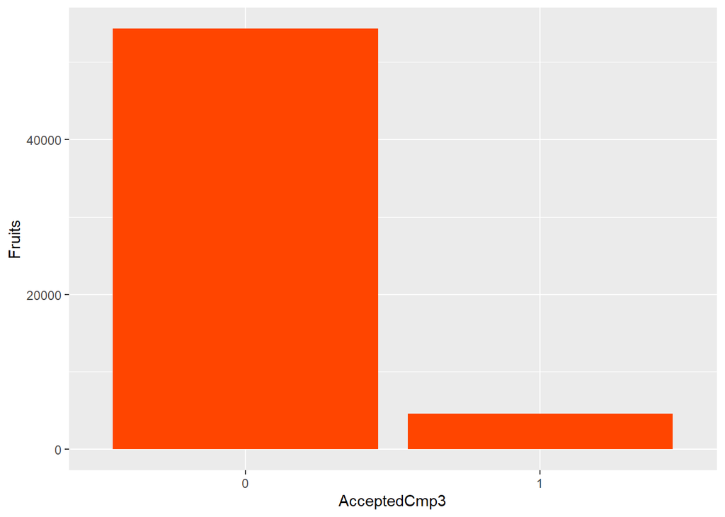

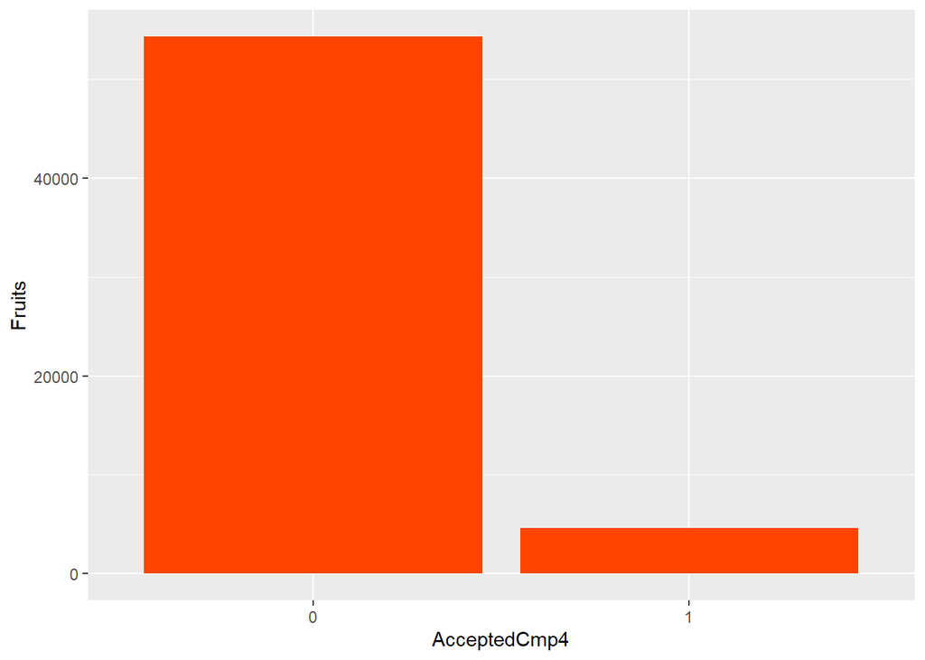

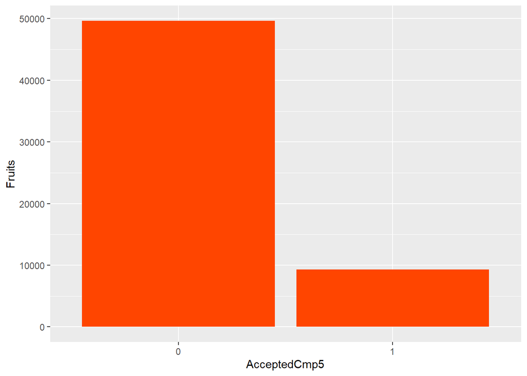

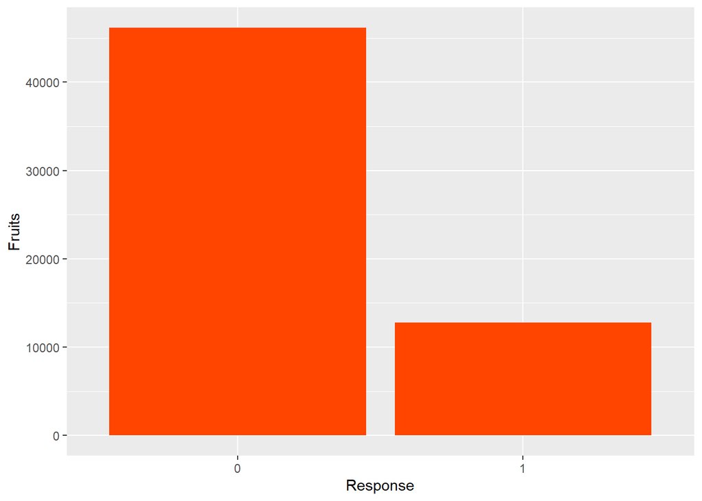

```r
library(ggplot2)
ggplot(new_data, aes(x=AcceptedCmp1, y=Fruits)) +
  geom_bar(stat = "identity", fill="orangered")
ggplot(new_data, aes(x=AcceptedCmp2, y=Fruits)) +
  geom_bar(stat = "identity", fill="orangered")
ggplot(new_data, aes(x=AcceptedCmp3, y=Fruits)) +
  geom_bar(stat = "identity", fill="orangered")
ggplot(new_data, aes(x=AcceptedCmp4, y=Fruits)) +
  geom_bar(stat = "identity", fill="orangered")
ggplot(new_data, aes(x=AcceptedCmp5, y=Fruits)) +
  geom_bar(stat = "identity", fill="orangered")
ggplot(new_data, aes(x=Response, y=Fruits)) +
  geom_bar(stat = "identity", fill="orangered")
```

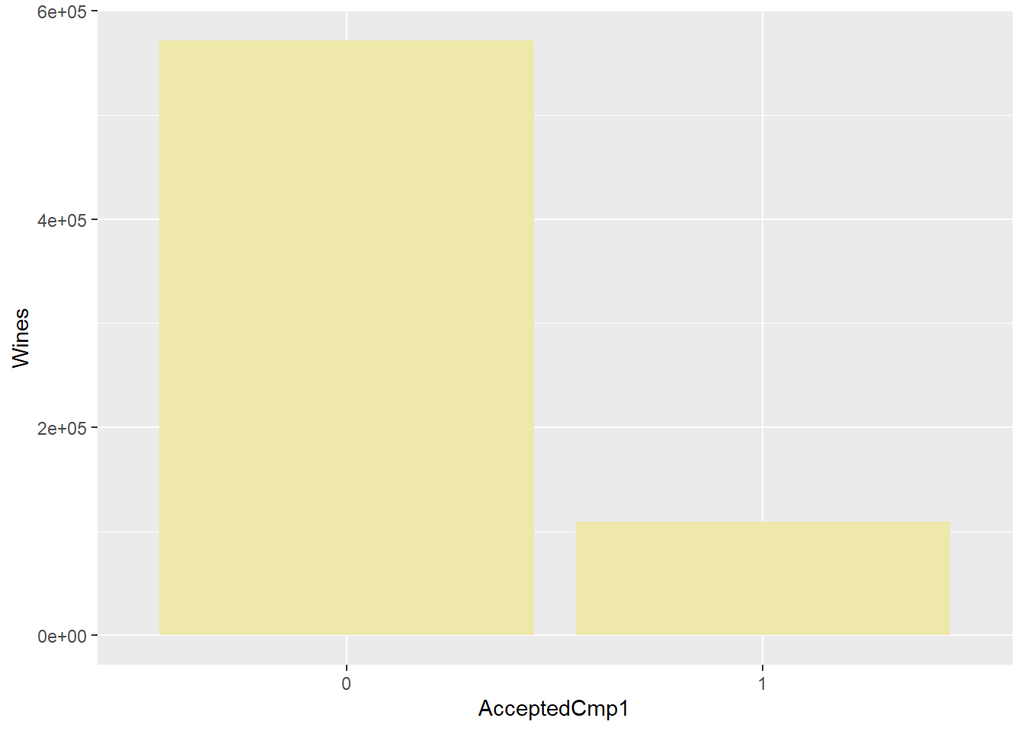

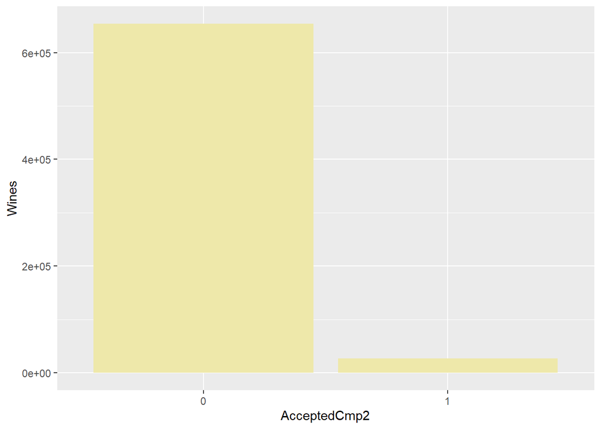

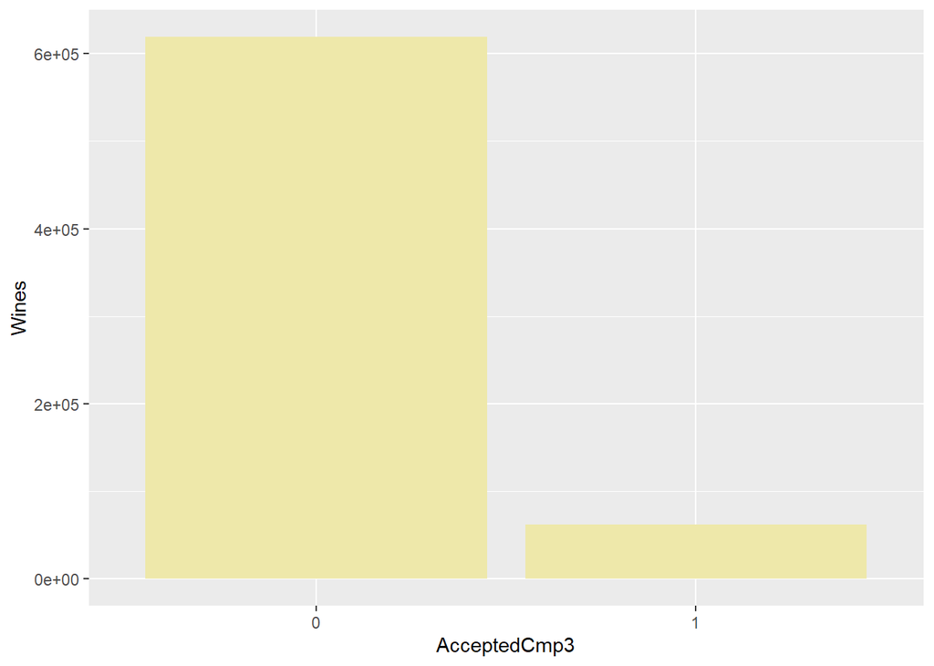

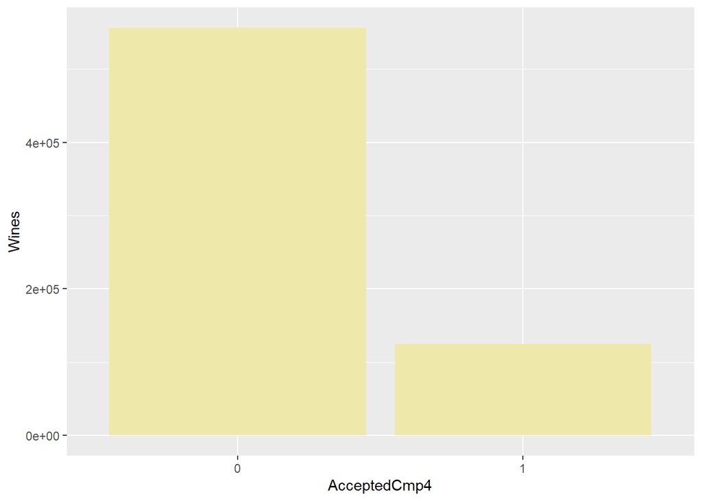

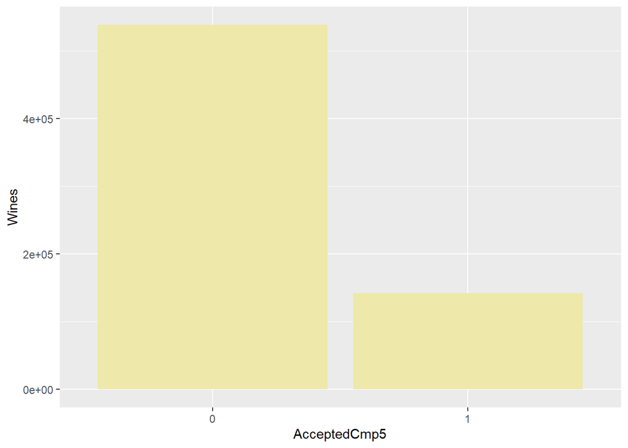

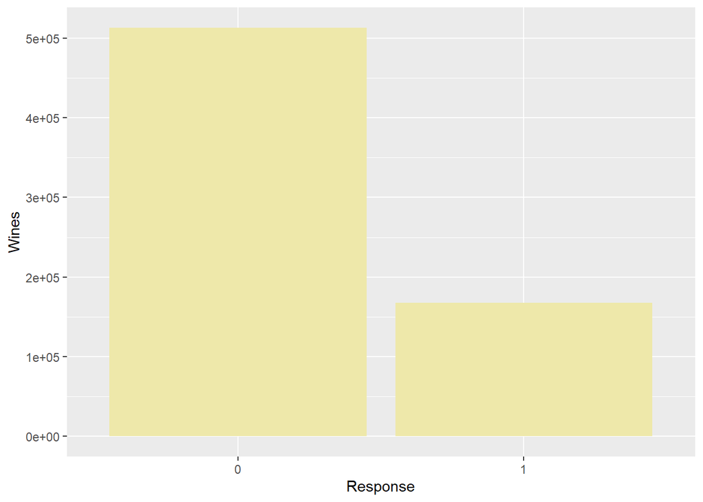

```r
library(ggplot2)
ggplot(new_data, aes(x=AcceptedCmp1, y=Wines)) +
  geom_bar(stat = "identity", fill="palegoldenrod")
ggplot(new_data, aes(x=AcceptedCmp2, y=Wines)) +
  geom_bar(stat = "identity", fill="palegoldenrod")
ggplot(new_data, aes(x=AcceptedCmp3, y=Wines)) +
  geom_bar(stat = "identity", fill="palegoldenrod")
ggplot(new_data, aes(x=AcceptedCmp4, y=Wines)) +
  geom_bar(stat = "identity", fill="palegoldenrod")
ggplot(new_data, aes(x=AcceptedCmp5, y=Wines)) +
  geom_bar(stat = "identity", fill="palegoldenrod")
ggplot(new_data, aes(x=Response, y=Wines)) +
  geom_bar(stat = "identity", fill="palegoldenrod")
```

By looking at other charts, we realize that other products behave like gold against advertising campaigns. It means that the last campaign had the most impact on them and the second campaign had the least impact.

### The effect of campaigns on number of purchases

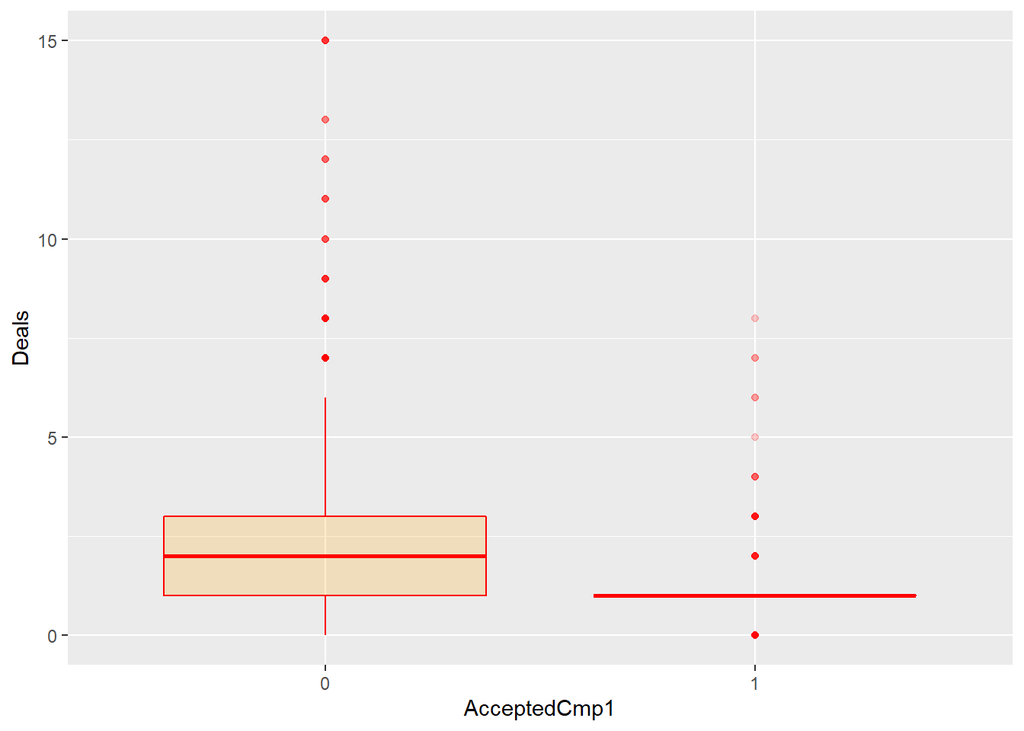

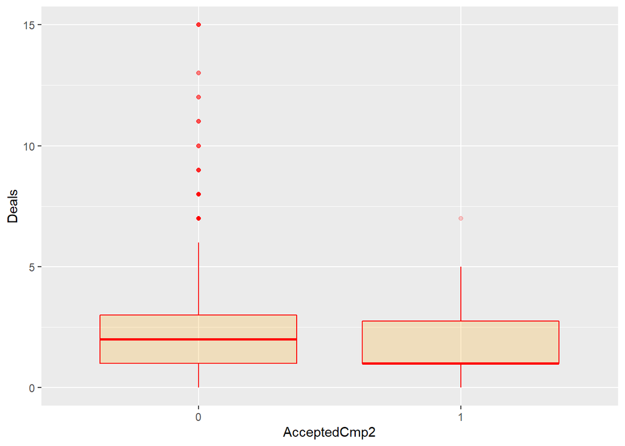

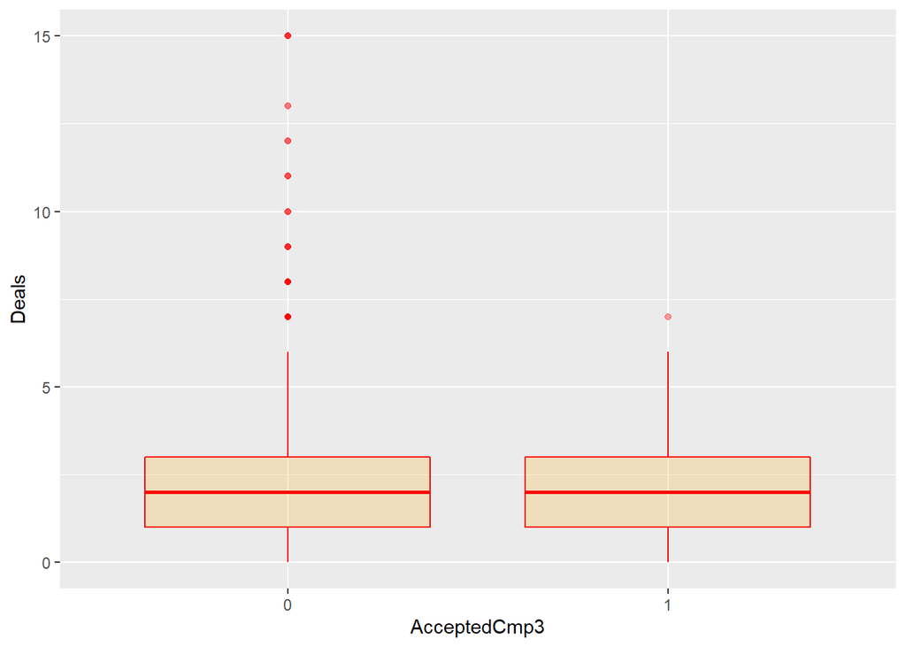

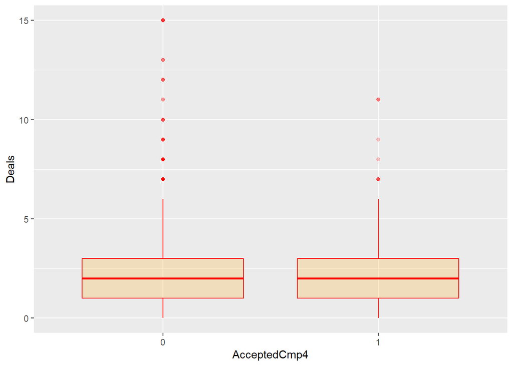

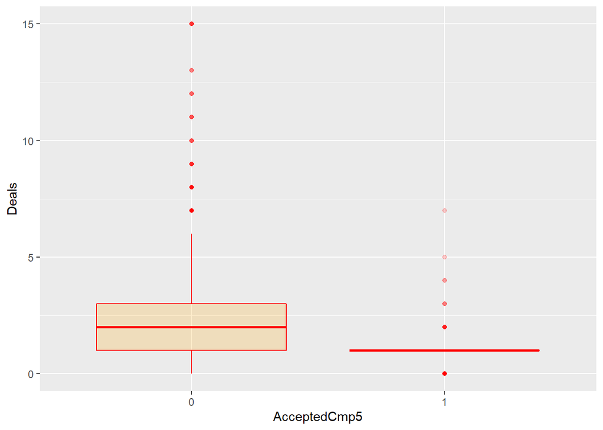

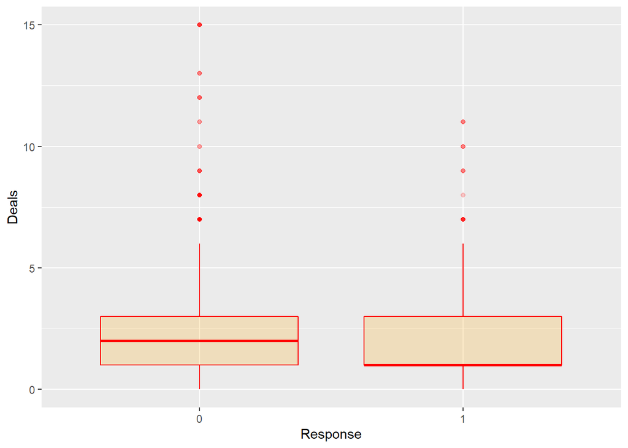

```r
library(ggplot2)
ggplot(new_data, aes(x=AcceptedCmp1, y=Deals)) +
    geom_boxplot(color="red", fill="orange", alpha=0.2)
ggplot(new_data, aes(x=AcceptedCmp2, y=Deals)) +
    geom_boxplot(color="red", fill="orange", alpha=0.2)
ggplot(new_data, aes(x=AcceptedCmp3, y=Deals)) +
    geom_boxplot(color="red", fill="orange", alpha=0.2)
ggplot(new_data, aes(x=AcceptedCmp4, y=Deals)) +
    geom_boxplot(color="red", fill="orange", alpha=0.2)
ggplot(new_data, aes(x=AcceptedCmp5, y=Deals)) +
    geom_boxplot(color="red", fill="orange", alpha=0.2)
ggplot(new_data, aes(x=Response, y=Deals)) +
    geom_boxplot(color="red", fill="orange", alpha=0.2)
```

In campaigns 3 and 4, the distribution of rejecters and accepters are the same, So it means that the effect of them on people are the same.

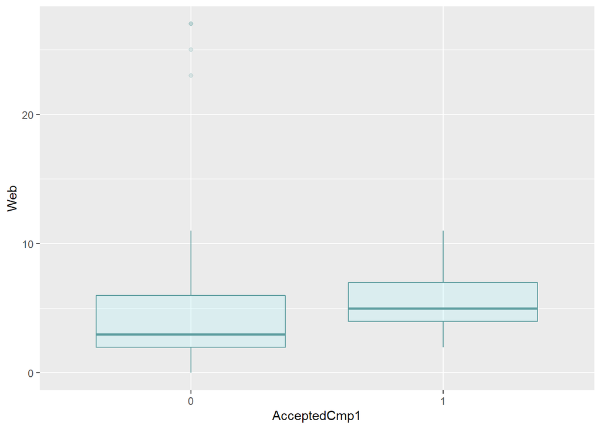

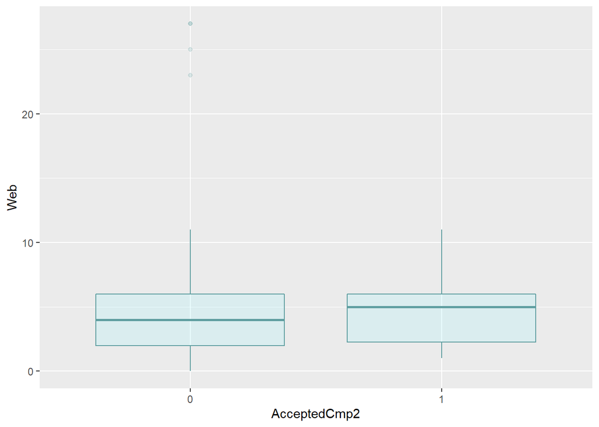

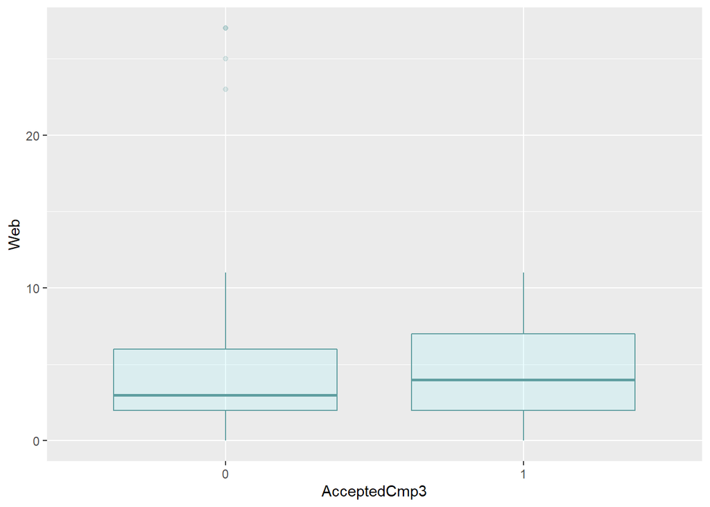

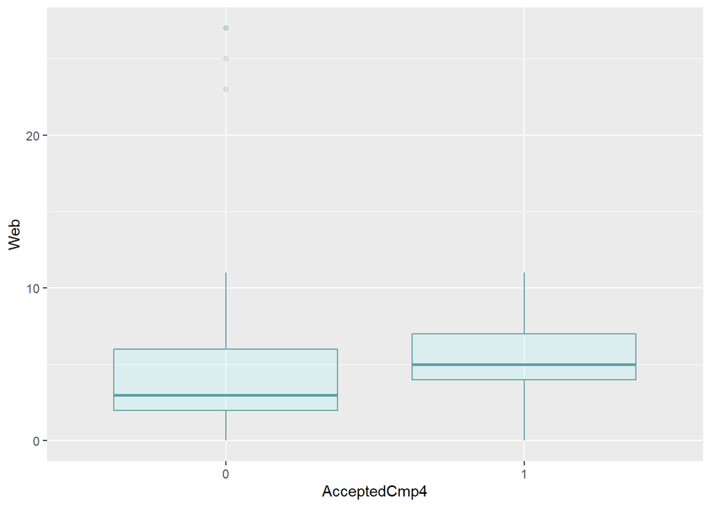

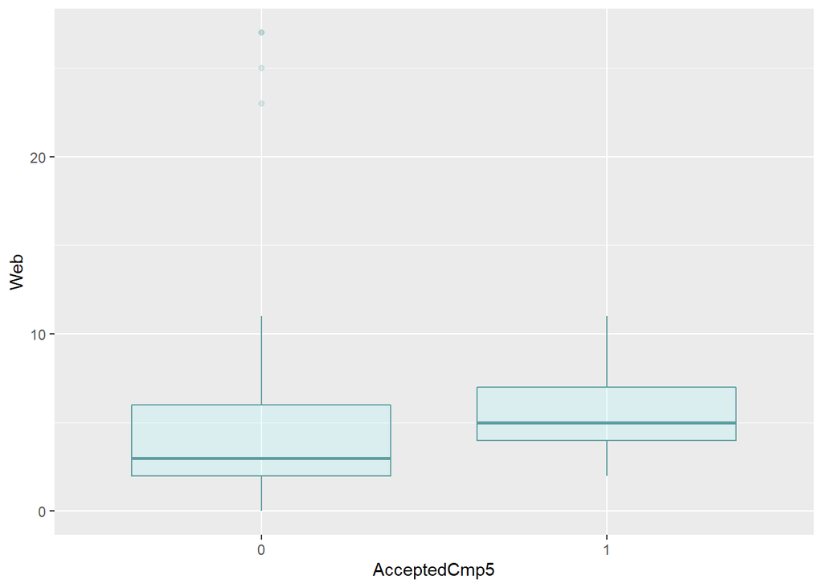

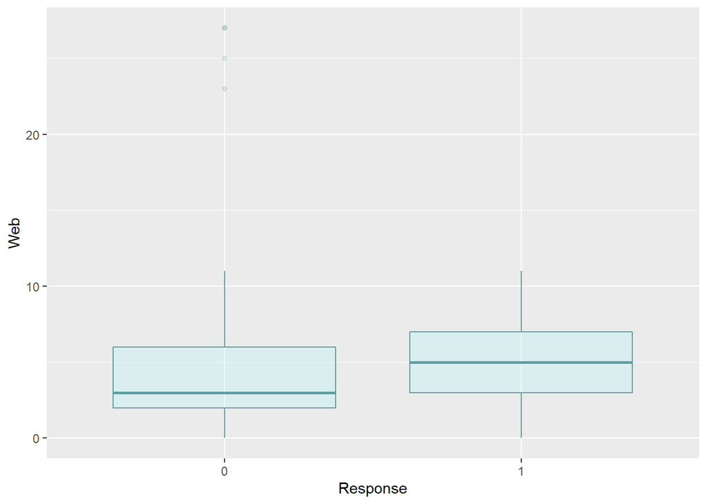

```r
library(ggplot2)
ggplot(new_data, aes(x=AcceptedCmp1, y=Web)) +
    geom_boxplot(color="cadetblue", fill="cadetblue1", alpha=0.2)
ggplot(new_data, aes(x=AcceptedCmp2, y=Web)) +
    geom_boxplot(color="cadetblue", fill="cadetblue1", alpha=0.2)
ggplot(new_data, aes(x=AcceptedCmp3, y=Web)) +
    geom_boxplot(color="cadetblue", fill="cadetblue1", alpha=0.2)
ggplot(new_data, aes(x=AcceptedCmp4, y=Web)) +
    geom_boxplot(color="cadetblue", fill="cadetblue1", alpha=0.2)
ggplot(new_data, aes(x=AcceptedCmp5, y=Web)) +
    geom_boxplot(color="cadetblue", fill="cadetblue1", alpha=0.2)
ggplot(new_data, aes(x=Response, y=Web)) +
    geom_boxplot(color="cadetblue", fill="cadetblue1", alpha=0.2)
```

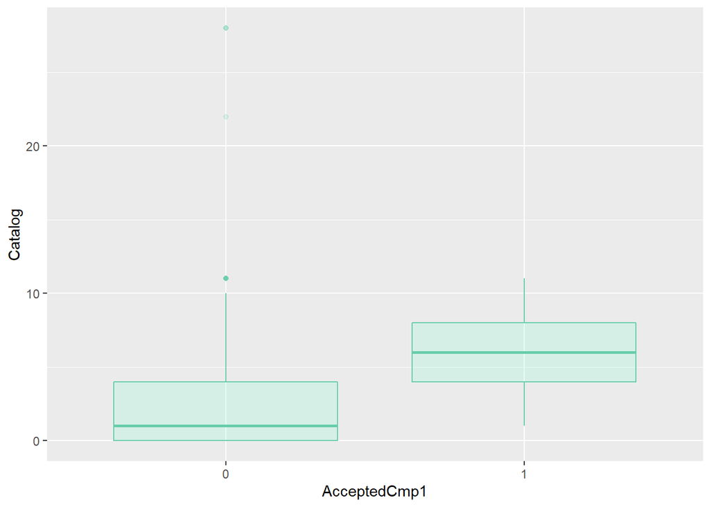

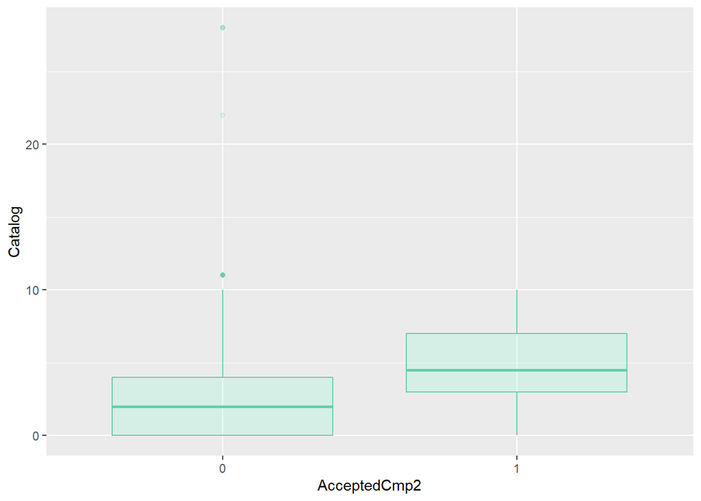

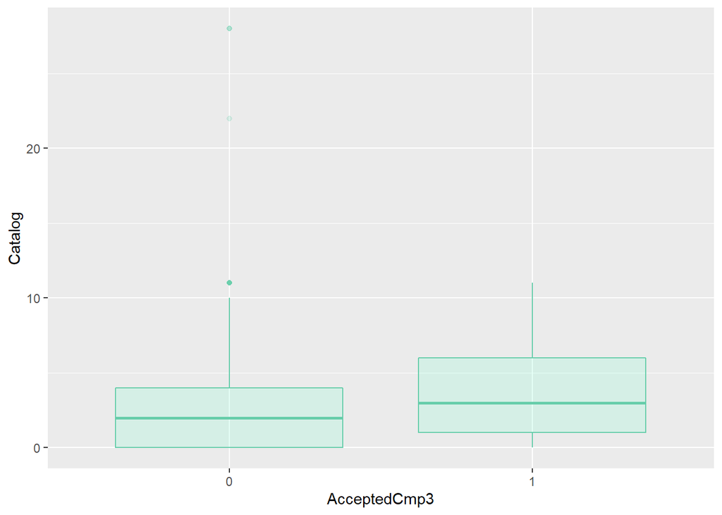

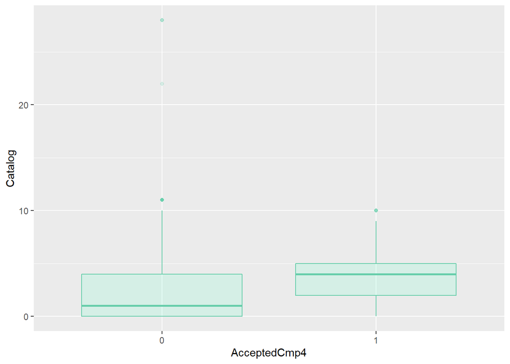

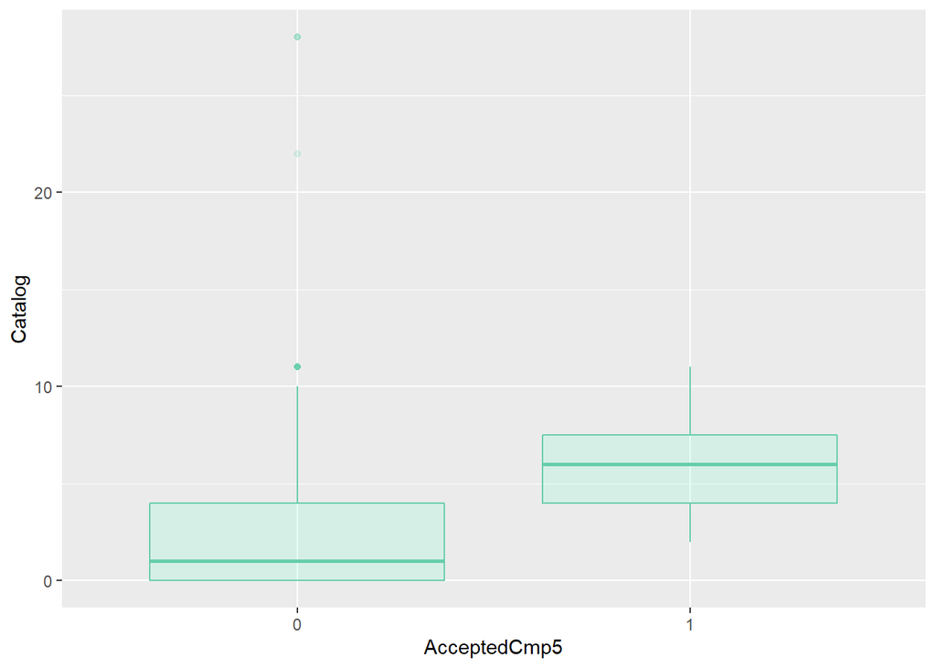

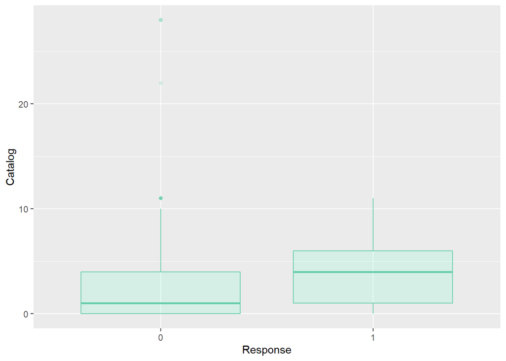

```r
library(ggplot2)
ggplot(new_data, aes(x=AcceptedCmp1, y=Catalog)) +
    geom_boxplot(color="aquamarine3", fill="aquamarine", alpha=0.2)
ggplot(new_data, aes(x=AcceptedCmp2, y=Catalog)) +
    geom_boxplot(color="aquamarine3", fill="aquamarine", alpha=0.2)
ggplot(new_data, aes(x=AcceptedCmp3, y=Catalog)) +
    geom_boxplot(color="aquamarine3", fill="aquamarine", alpha=0.2)
ggplot(new_data, aes(x=AcceptedCmp4, y=Catalog)) +
    geom_boxplot(color="aquamarine3", fill="aquamarine", alpha=0.2)
ggplot(new_data, aes(x=AcceptedCmp5, y=Catalog)) +
    geom_boxplot(color="aquamarine3", fill="aquamarine", alpha=0.2)
ggplot(new_data, aes(x=Response, y=Catalog)) +
    geom_boxplot(color="aquamarine3", fill="aquamarine", alpha=0.2)
```

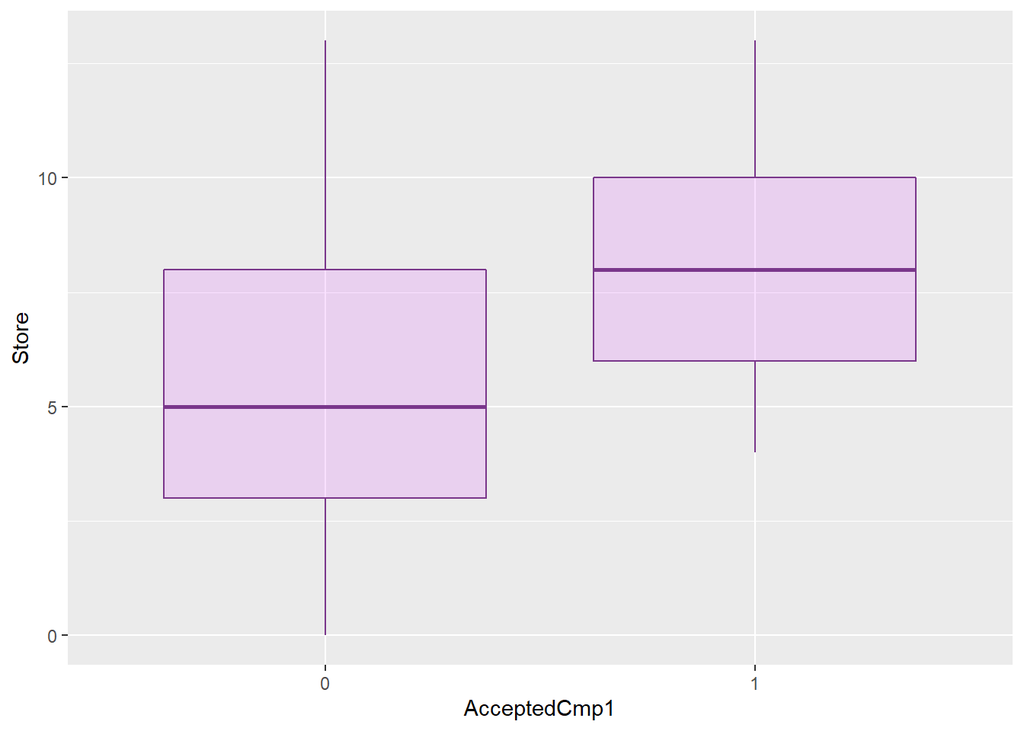

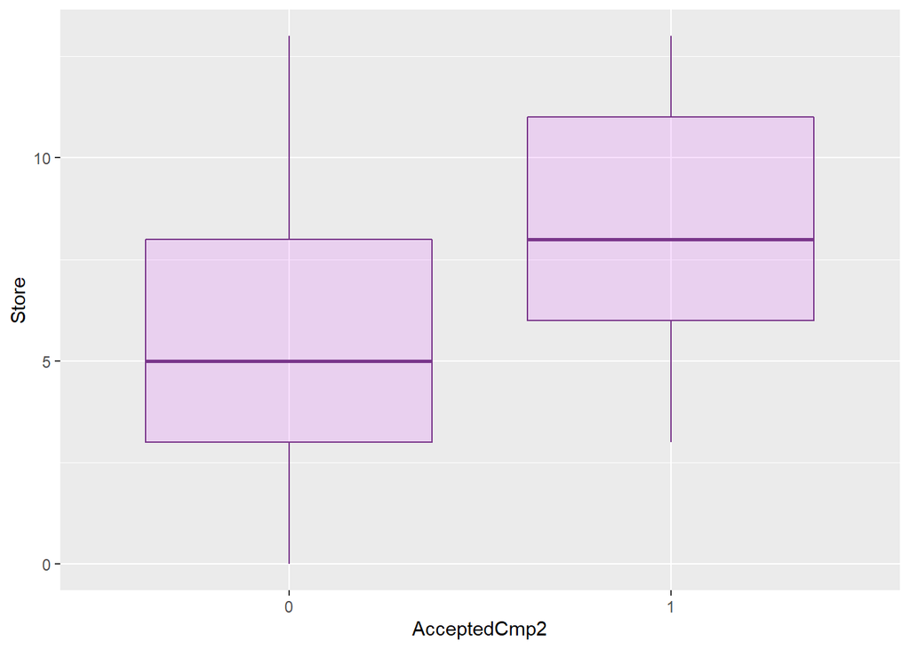

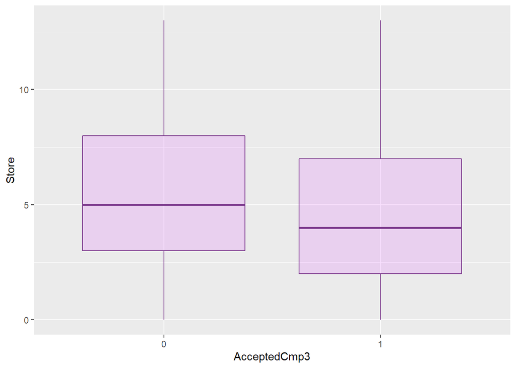

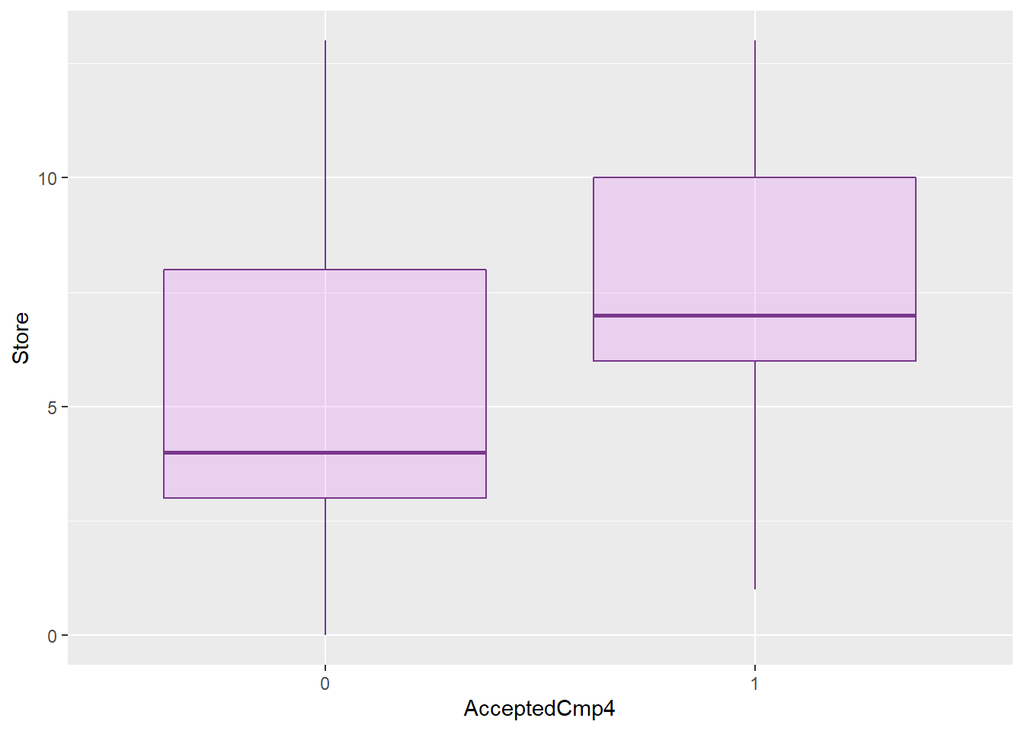

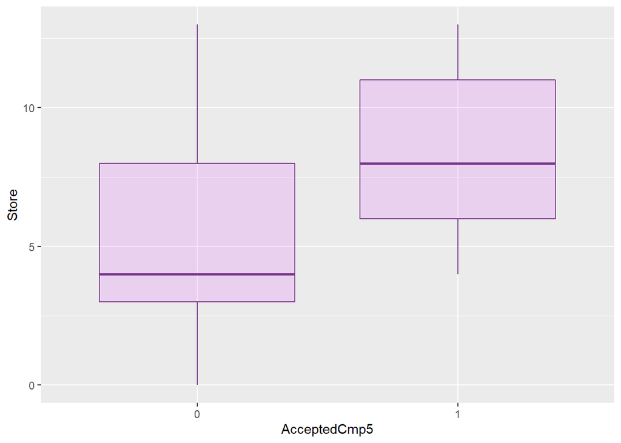

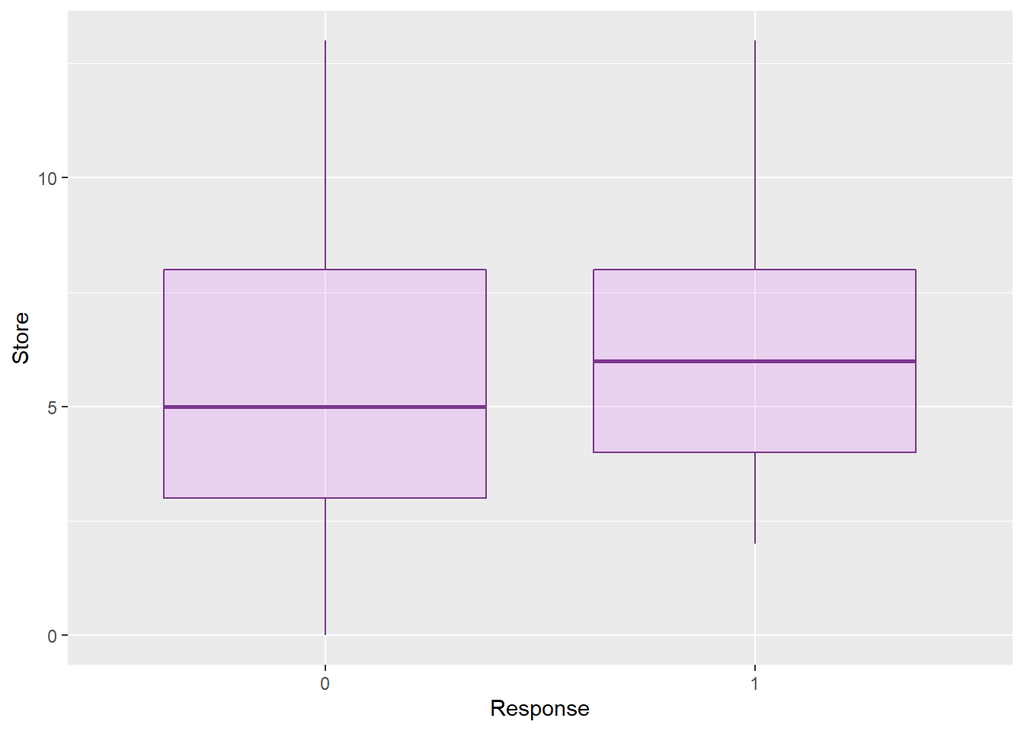

```r
library(ggplot2)
ggplot(new_data, aes(x=AcceptedCmp1, y=Store)) +
    geom_boxplot(color="mediumorchid4", fill="mediumorchid1", alpha=0.2)
ggplot(new_data, aes(x=AcceptedCmp2, y=Store)) +
    geom_boxplot(color="mediumorchid4", fill="mediumorchid1", alpha=0.2)
ggplot(new_data, aes(x=AcceptedCmp3, y=Store)) +
    geom_boxplot(color="mediumorchid4", fill="mediumorchid1", alpha=0.2)
ggplot(new_data, aes(x=AcceptedCmp4, y=Store)) +
    geom_boxplot(color="mediumorchid4", fill="mediumorchid1", alpha=0.2)
ggplot(new_data, aes(x=AcceptedCmp5, y=Store)) +
    geom_boxplot(color="mediumorchid4", fill="mediumorchid1", alpha=0.2)
ggplot(new_data, aes(x=Response, y=Store)) +
    geom_boxplot(color="mediumorchid4", fill="mediumorchid1", alpha=0.2)
```

People who accepted the campaigns 1, 2 and 5, have the highest median compared to others. Ergo they must have the highest store purchases.

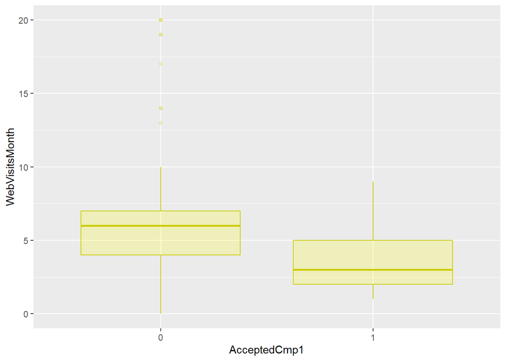

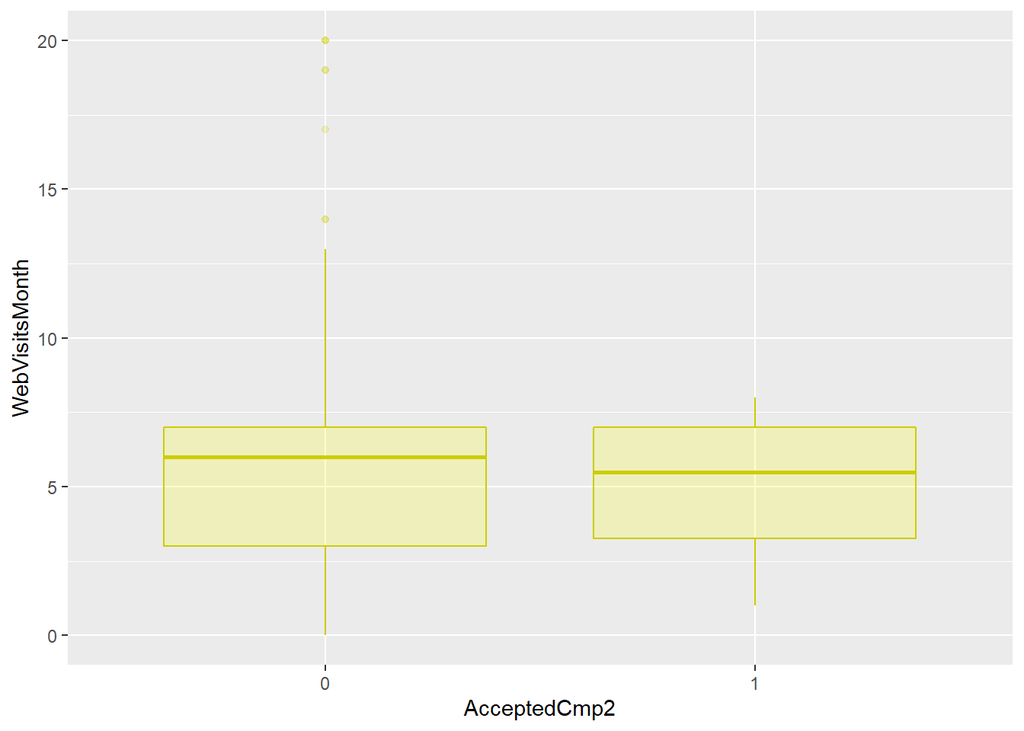

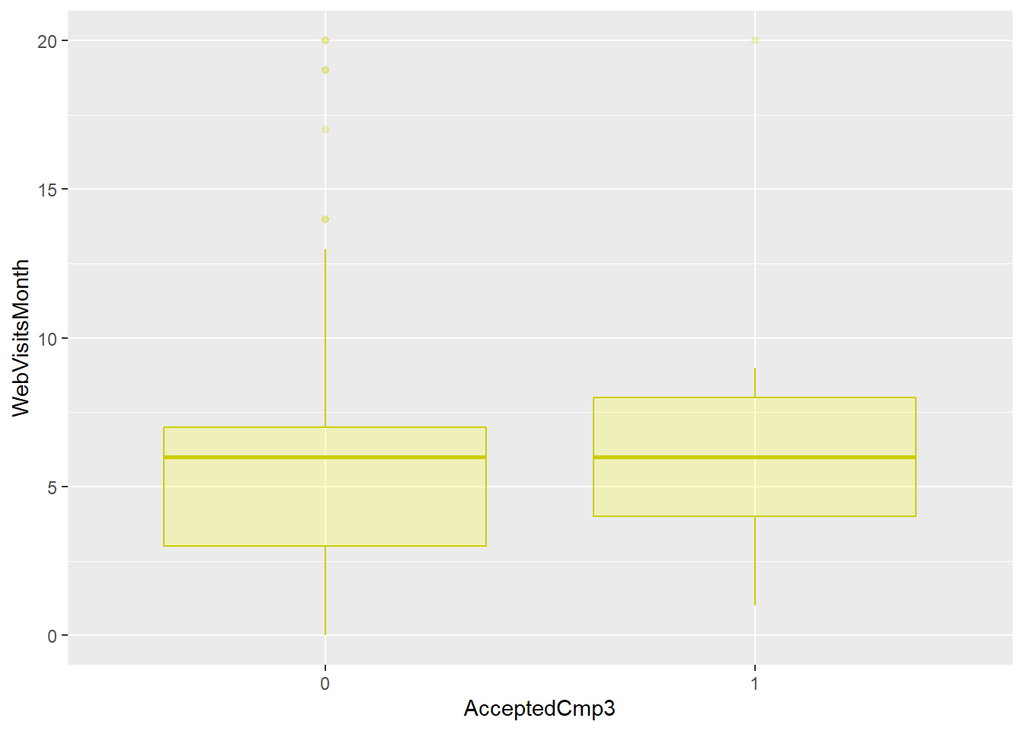

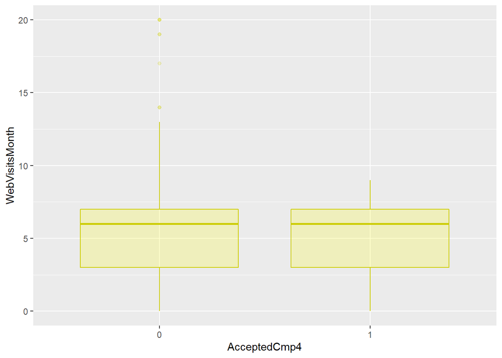

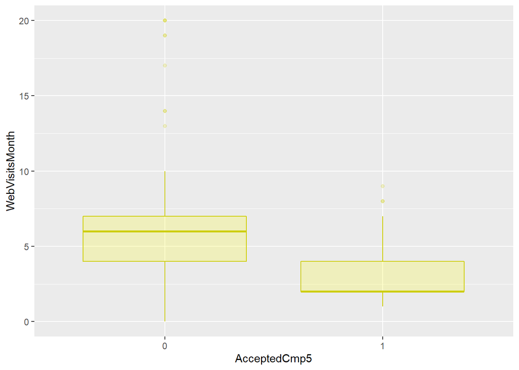

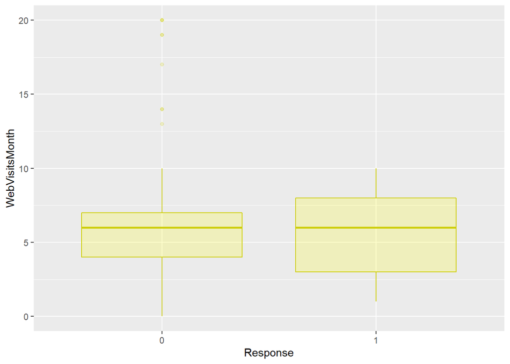

```r
library(ggplot2)
ggplot(new_data, aes(x=AcceptedCmp1, y=WebVisitsMonth)) +
    geom_boxplot(color="yellow3", fill="yellow", alpha=0.2)
ggplot(new_data, aes(x=AcceptedCmp2, y=WebVisitsMonth)) +
    geom_boxplot(color="yellow3", fill="yellow", alpha=0.2)
ggplot(new_data, aes(x=AcceptedCmp3, y=WebVisitsMonth)) +
    geom_boxplot(color="yellow3", fill="yellow", alpha=0.2)
ggplot(new_data, aes(x=AcceptedCmp4, y=WebVisitsMonth)) +
    geom_boxplot(color="yellow3", fill="yellow", alpha=0.2)
ggplot(new_data, aes(x=AcceptedCmp5, y=WebVisitsMonth)) +
    geom_boxplot(color="yellow3", fill="yellow", alpha=0.2)
ggplot(new_data, aes(x=Response, y=WebVisitsMonth)) +
    geom_boxplot(color="yellow3", fill="yellow", alpha=0.2)
```

People who accepted the campaigns 1 and 5, have the lowest median compared to others. Ergo they must have the lowest rate of visits to website. This fact completely makes sense according to the above interpretation, because people who accepted these campaigns do their purchases in person and they don’t buy online.

### The effect of campaigns on customers

#### Year_Birth:

First, we take a look at the distribution and details of the birth variable.

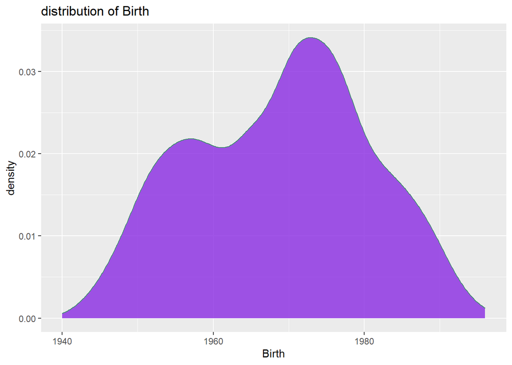

```r
new_data %>%
  ggplot( aes(x=Birth)) +
    geom_density(fill="blueviolet", color="aquamarine4", alpha=0.8) +
    ggtitle("distribution of Birth")
```

```r
summary(Birth)
```

```
##    Min. 1st Qu.  Median    Mean 3rd Qu.    Max.
##    1940    1959    1970    1969    1977    1996
```

Now, in order to find out which age groups the advertising campaigns had an impact on, we use the following graphs. Note that in each graph, the black color of the bars is a sign that the advertising campaign has no effect on that age group.

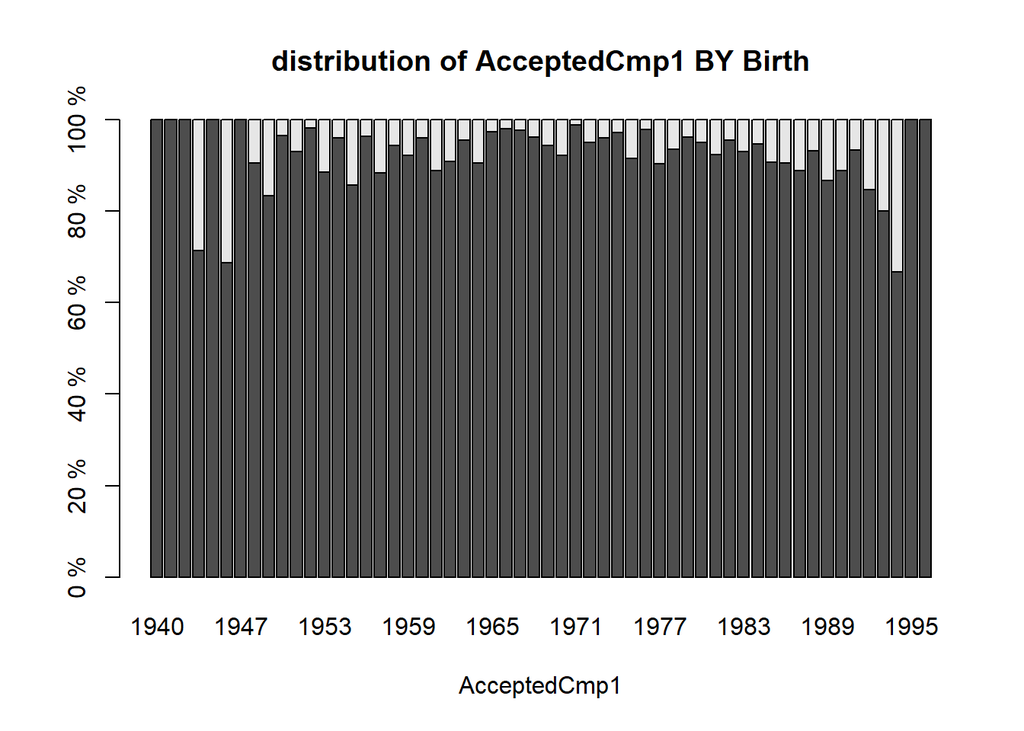

```r
table1=table(AcceptedCmp1,Birth)
prop.table=prop.table(table1,margin = 2)
barplot(prop.table,xlab = "AcceptedCmp1",ylab="",
        yaxt="n",main="distribution of AcceptedCmp1 BY Birth")
axis(2,at=(seq(0,1,0.2)),paste(seq(0,100,20),"%"))
```

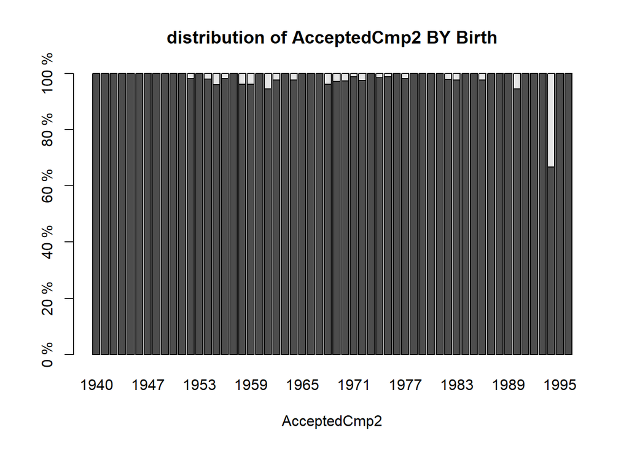

```r
table2=table(AcceptedCmp2,Birth)
prop.table=prop.table(table2,margin = 2)
barplot(prop.table,xlab = "AcceptedCmp2",ylab="",
        yaxt="n",main="distribution of AcceptedCmp2 BY Birth")
axis(2,at=(seq(0,1,0.2)),paste(seq(0,100,20),"%"))
```

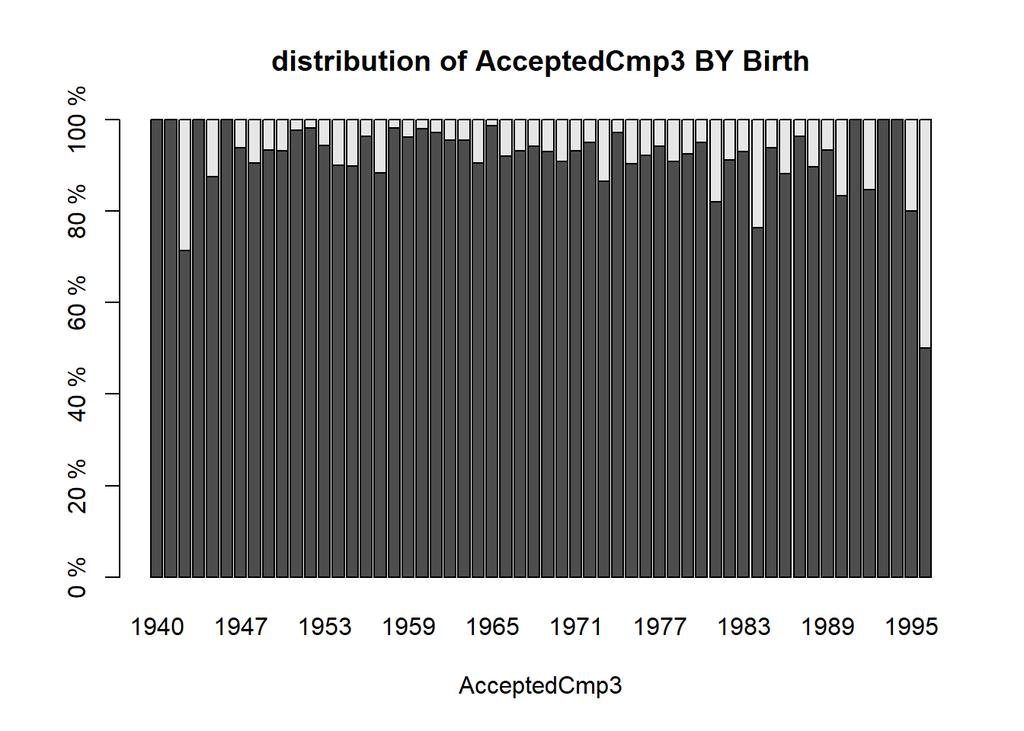

```r
table3=table(AcceptedCmp3,Birth)
prop.table=prop.table(table3,margin = 2)
barplot(prop.table,xlab = "AcceptedCmp3",ylab="",
        yaxt="n",main="distribution of AcceptedCmp3 BY Birth")
axis(2,at=(seq(0,1,0.2)),paste(seq(0,100,20),"%"))
```

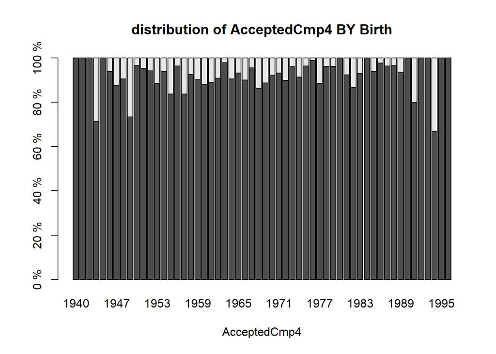

```r
table4=table(AcceptedCmp4,Birth)
prop.table=prop.table(table4,margin = 2)
barplot(prop.table,xlab = "AcceptedCmp4",ylab="",
        yaxt="n",main="distribution of AcceptedCmp4 BY Birth")
axis(2,at=(seq(0,1,0.2)),paste(seq(0,100,20),"%"))
```

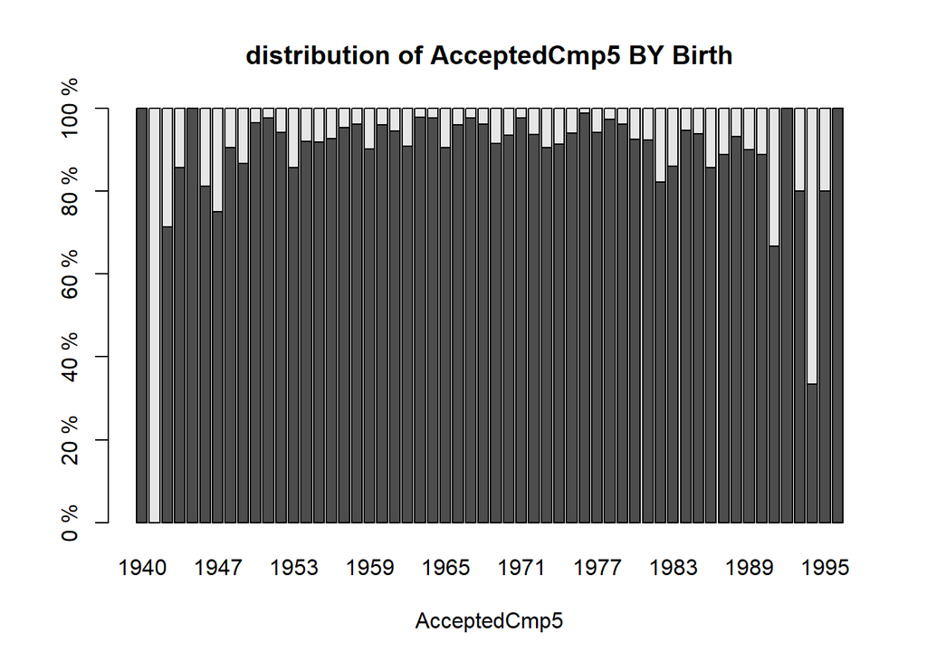

```r
table5=table(AcceptedCmp5,Birth)
prop.table=prop.table(table5,margin = 2)
barplot(prop.table,xlab = "AcceptedCmp5",ylab="",
        yaxt="n",main="distribution of AcceptedCmp5 BY Birth")
axis(2,at=(seq(0,1,0.2)),paste(seq(0,100,20),"%"))
```

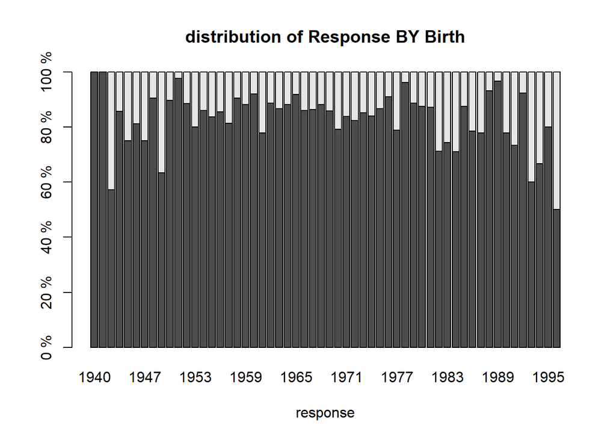

```r
table6=table(Response,Birth)
prop.table=prop.table(table6,margin = 2)
barplot(prop.table,xlab = "response",ylab="",
        yaxt="n",main="distribution of Response BY Birth")
axis(2,at=(seq(0,1,0.2)),paste(seq(0,100,20),"%"))
```

As it is clear in the graphs above, among different age groups, the latest campaign has been the most accepted by customers. The second campaign has the least probability of success in attracting customers.

#### Education:

Education has 5 levels. We want to investigate the effect of advertising campaigns on people with different education levels.

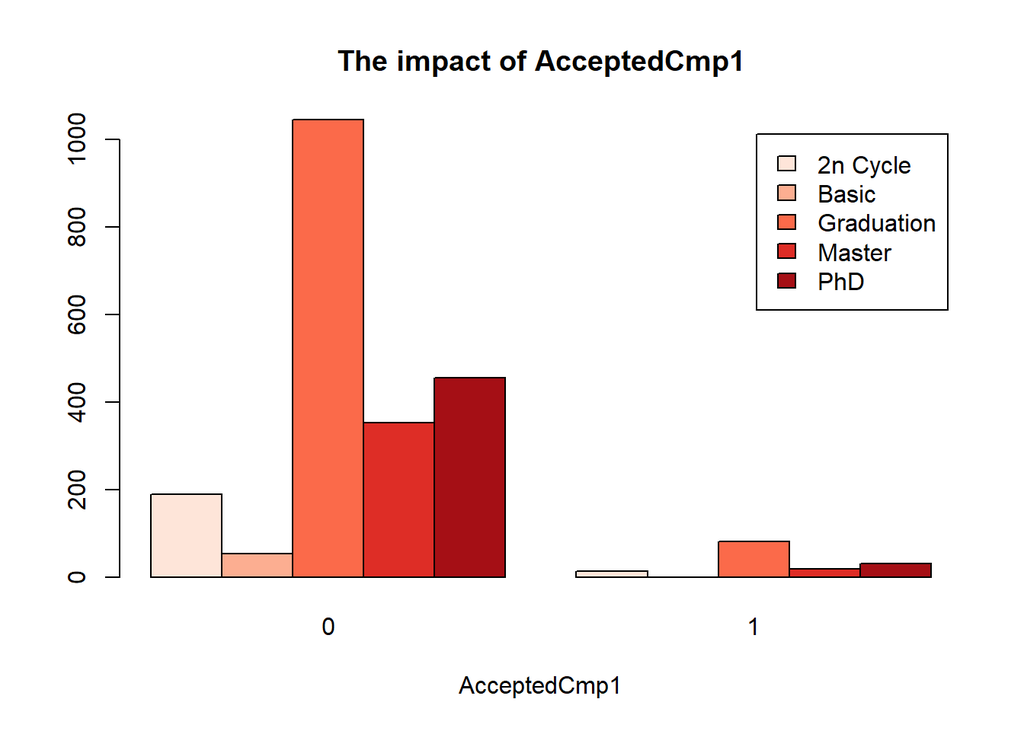

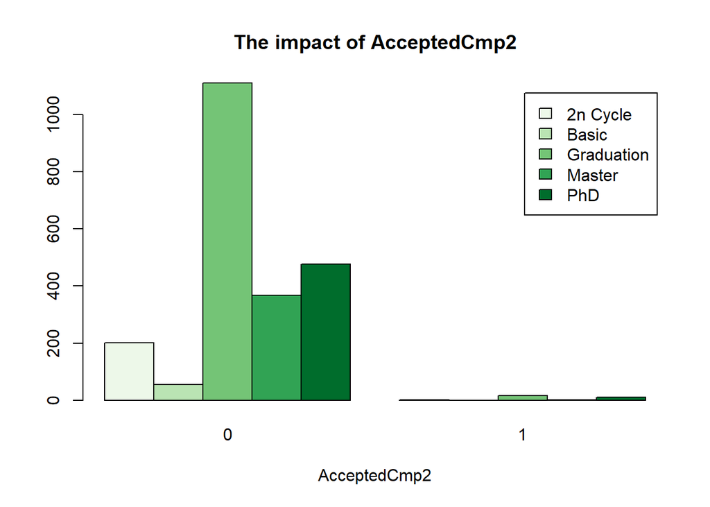

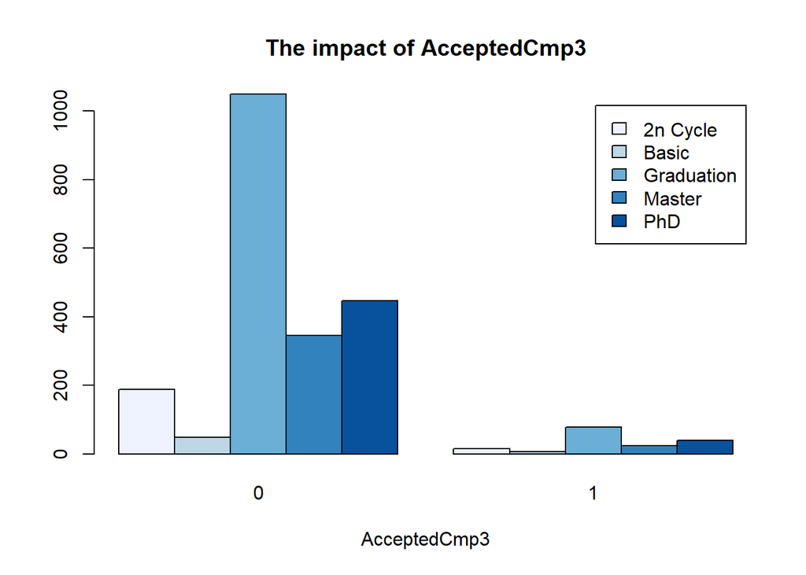

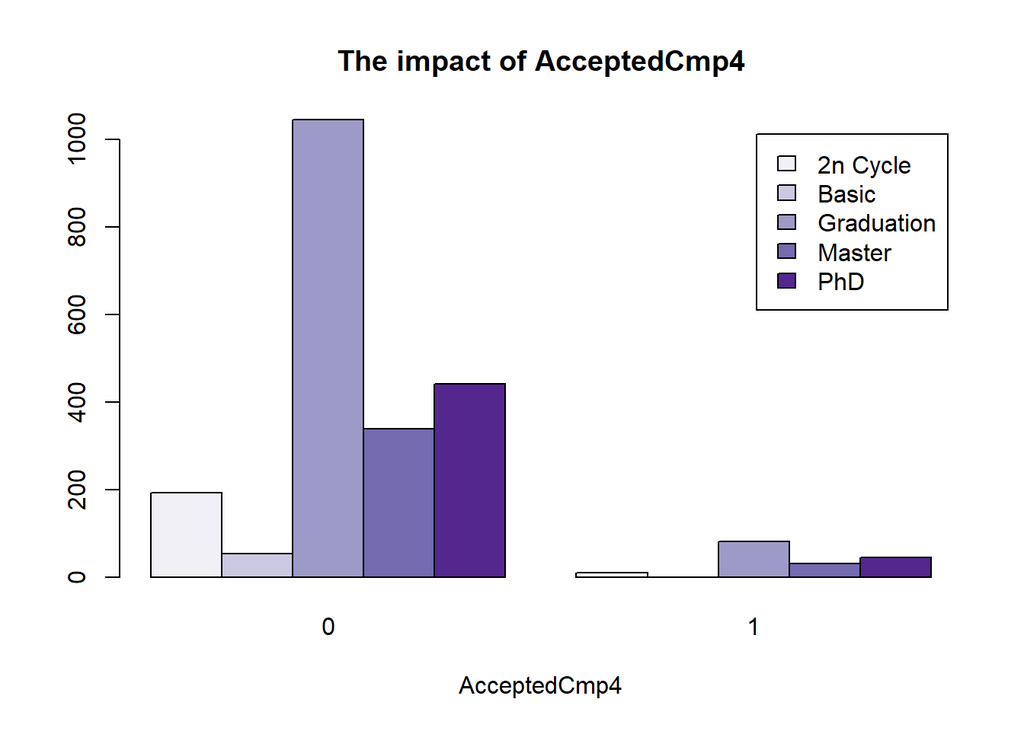

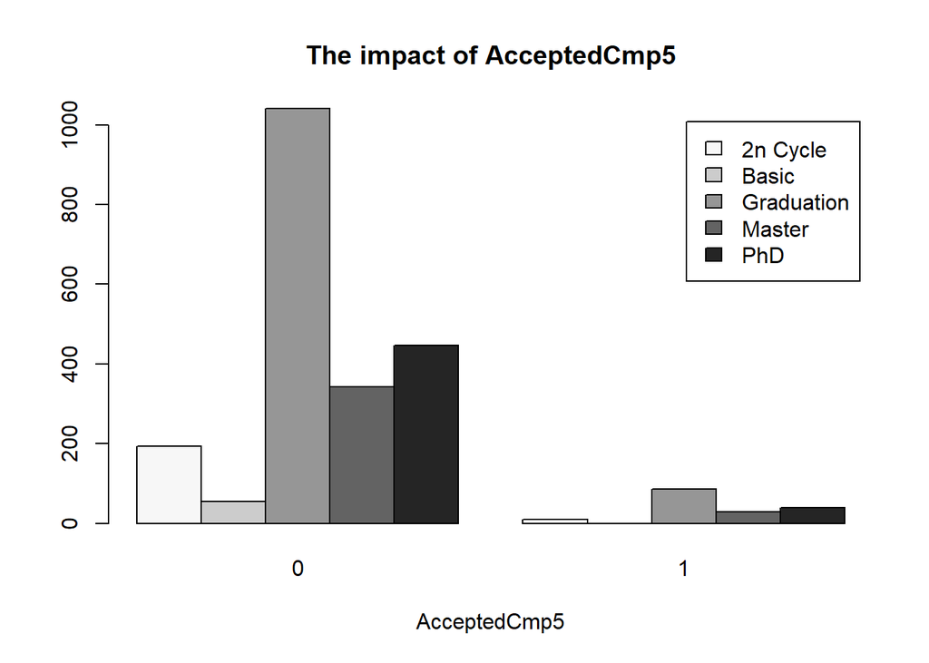

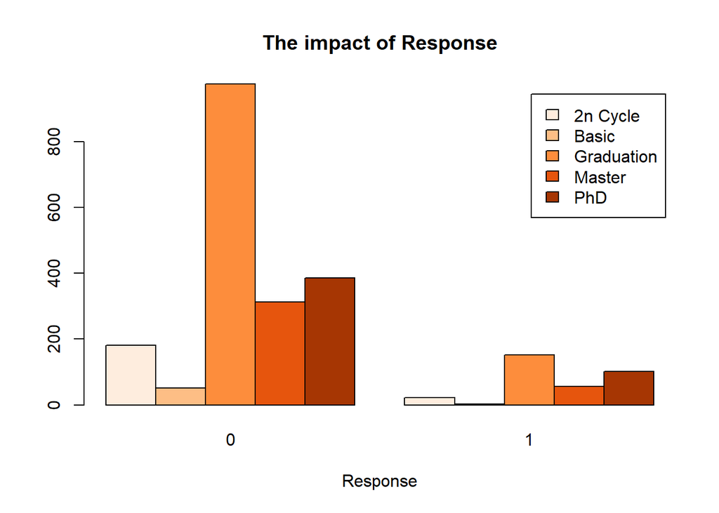

```r
library(RColorBrewer)
ed_acc1=table(Education,AcceptedCmp1)
col1=brewer.pal(5, "Reds")
barplot(ed_acc1,
        legend.text = TRUE,
        beside = TRUE,
        main = "The impact of AcceptedCmp1",
        xlab = "AcceptedCmp1",
        ylab = "",col=col1)

ed_acc2=table(Education,AcceptedCmp2)
col2=brewer.pal(5, "Greens")
barplot(ed_acc2,
        legend.text = TRUE,
        beside = TRUE,
        main = "The impact of AcceptedCmp2",
        xlab = "AcceptedCmp2",
        ylab = "",col=col2)

ed_acc3=table(Education,AcceptedCmp3)
col3=brewer.pal(5, "Blues")
barplot(ed_acc3,
        legend.text = TRUE,
        beside = TRUE,
        main = "The impact of AcceptedCmp3",
        xlab = "AcceptedCmp3",
        ylab = "",col=col3)

ed_acc4=table(Education,AcceptedCmp4)
col4=brewer.pal(5, "Purples")
barplot(ed_acc4,
        legend.text = TRUE,
        beside = TRUE,
        main = "The impact of AcceptedCmp4",
        xlab = "AcceptedCmp4",
        ylab = "",col=col4)

ed_acc5=table(Education,AcceptedCmp5)
col5=brewer.pal(5, "Greys")
barplot(ed_acc5,
        legend.text = TRUE,
        beside = TRUE,
        main = "The impact of AcceptedCmp5",
        xlab = "AcceptedCmp5",
        ylab = "",col=col5)

ed_res=table(Education,Response)
col6=brewer.pal(5, "Oranges")
barplot(ed_res,
        legend.text = TRUE,
        beside = TRUE,
        main = "The impact of Response",
        xlab = "Response",
        ylab = "",col=col6)
```

The rejection of all of the campaigns have almost the same distribution among different education levels. The highest number of rejection among all education levels in all of the campaigns, is the graduation level. And the lowest of them all, is the basic level.

#### Marital Status:

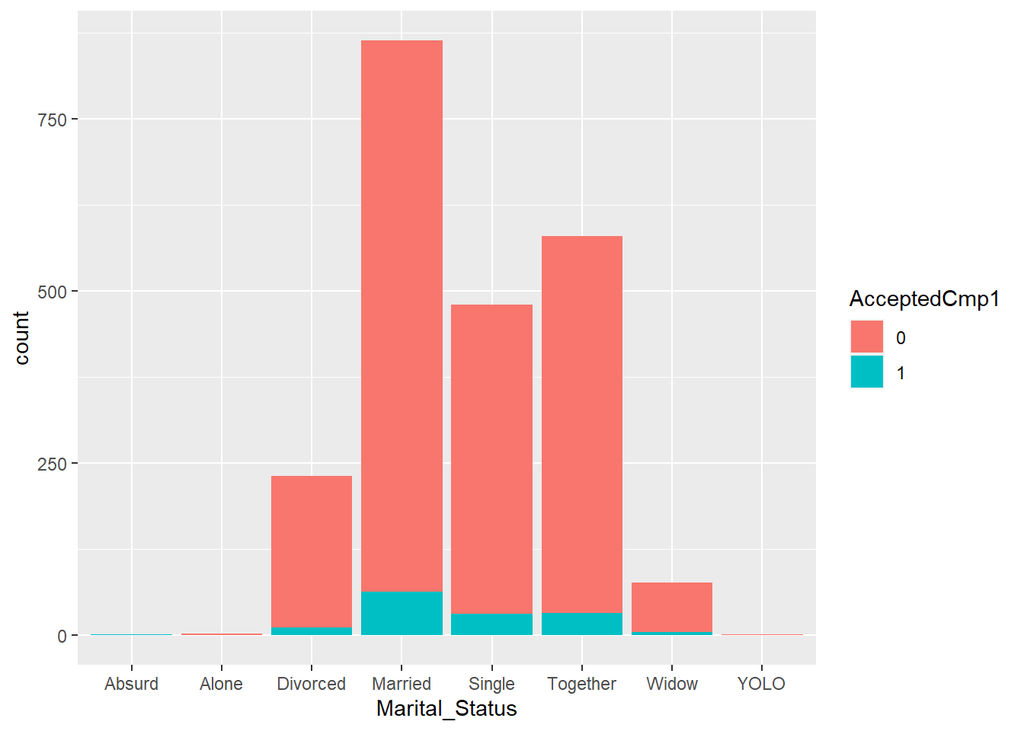

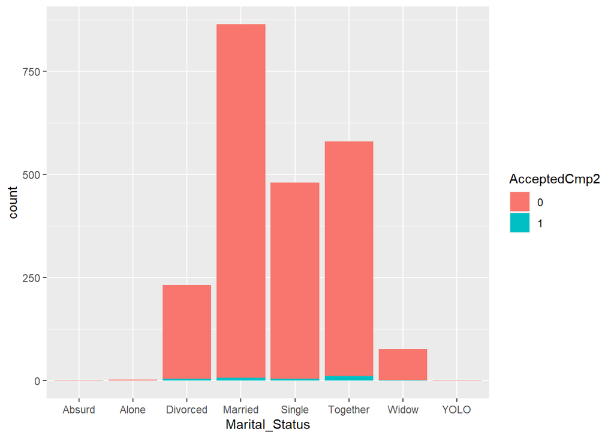

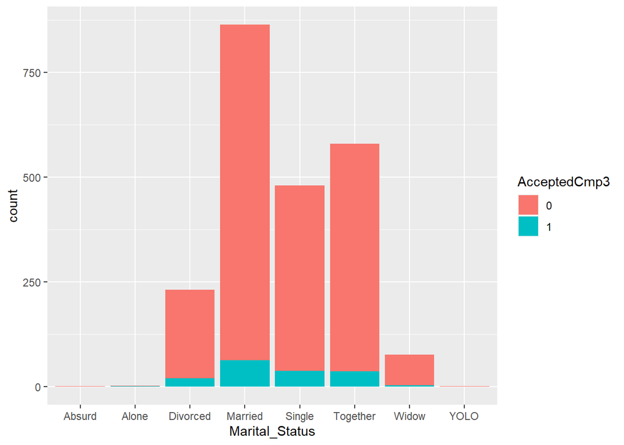

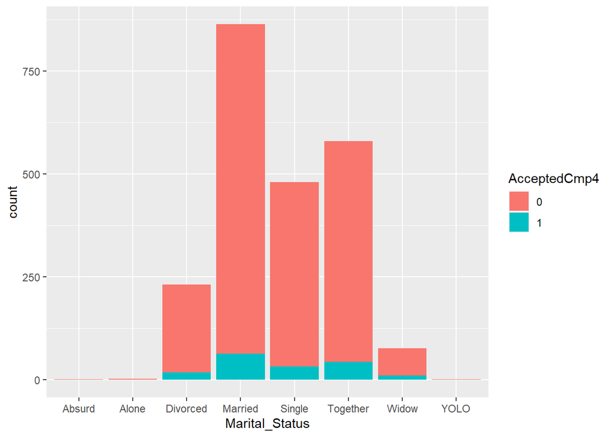

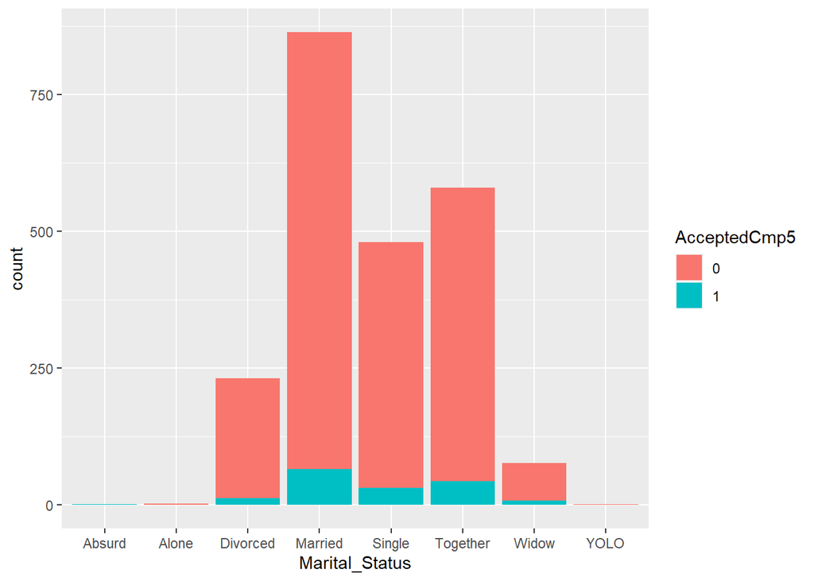

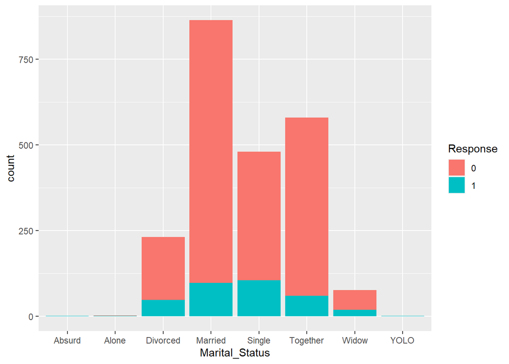

```r
library(ggplot2)
ggplot(new_data, aes(x = Marital_Status,fill = AcceptedCmp1)) + geom_bar()
ggplot(new_data, aes(x = Marital_Status,fill = AcceptedCmp2)) + geom_bar()
ggplot(new_data, aes(x = Marital_Status,fill = AcceptedCmp3)) + geom_bar()
ggplot(new_data, aes(x = Marital_Status,fill = AcceptedCmp4)) + geom_bar()
ggplot(new_data, aes(x = Marital_Status,fill = AcceptedCmp5)) + geom_bar()
ggplot(new_data, aes(x = Marital_Status,fill = Response)) + geom_bar()
```

The highest acceptance rate in campaigns 1,3,4 and 5 belongs to married people. \ And the above statement is true for campaign 2 with “together” status. Above all, the last campaign had the most acceptance rate, especially in “single” status.